# California Red Sea Urchin

CDFW Project 2016

Adrian Hordyk, University of British Columbia.

June 2017

# Introduction

This OM was built as part of a project with the California Department of Fish and Wildlife to evaluate DLMtool for use in California state-managed marine fisheries.

The goal of the project was to demonstrate an efficient and transparent framework for improving the science for data-limited fisheries and for prioritizing future data collection.

Through close collaboration with CDFW biologists, the project has conducted case studies with four stocks: barred sand bass, Southern California halibut, red sea urchin, and warty sea cucumber. A current project with CDFW, which commenced in February 2018, will update the OM for these cases studies, as well as build OM for several more data-limited fisheries in California.

This document describes the OM for the red sea urchin. Several features have been added to DLMtool (e.g., historical MPAs, retention curves and discard mortality) since this OM was built. Default assumptions for these parameters have been made in this OM, and the OM will be updated as part of the 2018 project.

# Operating Model

The OM rdata file can be downloaded from here

Download and import into R using `myOM <- readRDS('OM.rdata')`

## Species Information

**Species**: *Mesocentrotus franciscanus*

**Common Name**: *Red Sea Urchin*

**Management Agency**: CDFW

**Region**: California, USA

**Sponsor**: Resource Legacy Fund

**Latitude**: 34.42083

**Longitude**: -119.69819

## OM Parameters

**OM Name**: Name of the operating model: RSU_CA

**nsim**: The number of simulations: 500

**proyears**: The number of projected years: 50

**interval**: The assessment interval - how often would you like to update the management system? 4

**pstar**: The percentile of the sample of the management recommendation for each method: 0.5

**maxF**: Maximum instantaneous fishing mortality rate that may be simulated for any given age class: 0.8

**reps**: Number of samples of the management recommendation for each method. Note that when this is set to 1, the mean value of the data inputs is used. 1

**Source**: A reference to a website or article from which parameters were taken to define the operating model

See full [report](https://www.datalimitedtoolkit.org/wp-content/uploads/2017/07/Applying-MSE-to-CA-Fisheries-Case-Studies-Recommendations.pdf) for details

# Stock Parameters

### Mortality and age: maxage, R0, M, Msd

**maxage**: The maximum age of individuals that is simulated (there is no plus group ). Single value. Positive integer

Specified Value(s): 50

See M.

**R0**: The magnitude of unfished recruitment. Single value. Positive real number

Specified Value(s): 1e+05

Fixed at an arbitrary 100,000.

**M**: Natural mortality rate. Uniform distribution lower and upper bounds. Positive real number

Specified Value(s): 0.2, 0.32

In the early days of the fishery, the life span of red sea urchin was suggested to be 7 – 10 years. However, more recent work using tetracycline and calcein tagging has demonstrated that the longevity of the species if much greater, exceeding 100 years in British Columbia and Washington (Ebert and Southon 2003, Ebert 2008). The lifespan of red sea urchin in southern California appears to be much shorter, with few individuals reaching ages of 50 years (Ebert and Southon 2003).

Both growth and natural mortality have been found to vary spatially in northern California (Morgan et al. 2000). Natural mortality (M) has been estimated from 0.05 – 0.204 in northern California, and 0.088 – 0.4 in southern California (Ebert and Russell 1992, Ebert et al. 1999, Morgan et al. 2000). These fine-scale variations in M are thought to be related to greater abundance of sea urchin predators in southern California (Morgan et al. 2000). Sea urchin are believed to be slow-growing, and reach large sizes. This implies that maximum age must be quite high.

Ebert et al. (1999) estimated a mean annual survival probability of 0.77 yr-1 in southern California, which corresponds to a value of M of 0.26. This value was selected as the best estimate of M for red sea urchin in southern California, and given the high uncertainty in this parameter, a CV of 25% was assumed and the range for M defined as 0.195 – 0.32.  
Maximum age was set at 50 years, which is high enough that only a small proportion of the original cohort remains alive at maximum age for the full range of M values examined in the MSE.

**Msd**: Inter-annual variability in natural mortality rate expressed as a coefficient of variation. Uniform distribution lower and upper bounds. Non-negative real numbers

Specified Value(s): 0, 0.05

No justification provided.

### Natural Mortality Parameters

#### Sampled Parameters

Histograms of simulations of `M`, and `Msd` parameters, with vertical colored lines indicating 3 randomly drawn values used in other plots:

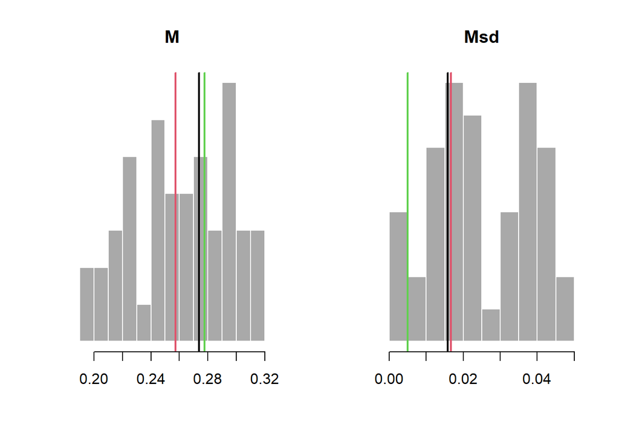

#### Time-Series

The average natural mortality rate by year for adult fish for 3 simulations. The vertical dashed line indicates the end of the historical period:

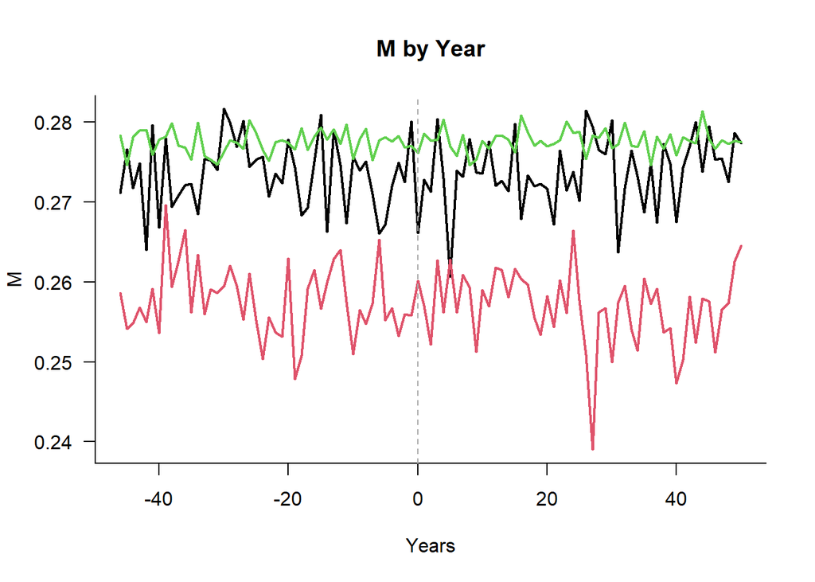

#### M-at-Age

Natural mortality-at-age for 3 simulations in the first historical year, the last historical year (i.e., current year), and the last projected year:

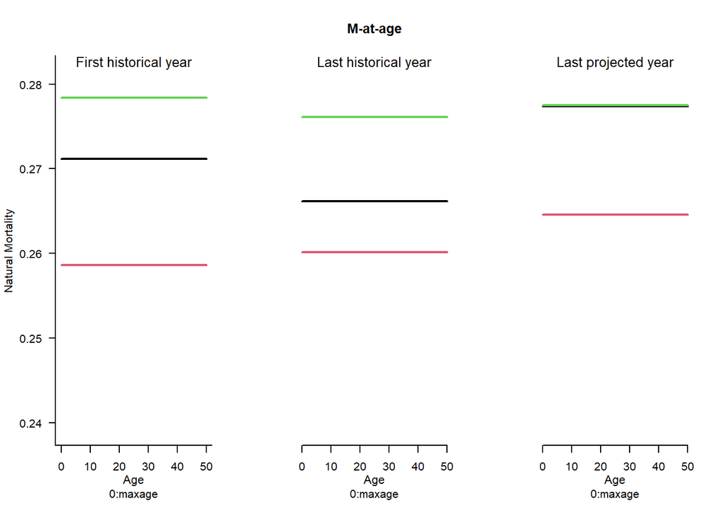

#### M-at-Length

Natural mortality-at-length for 3 simulations in the first historical year, the last historical year (i.e., current year), and the last projected year:

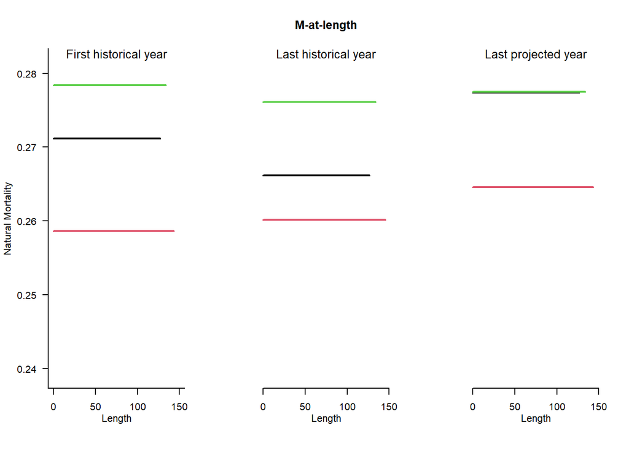

### Recruitment: h, SRrel, Perr, AC

**h**: Steepness of the stock recruit relationship. Uniform distribution lower and upper bounds. Values from 1/5 to 1

Specified Value(s): 0.4, 0.6

Recruitment appears to be episodic in northern California, Oregon, Washington, and British Columbia, but more stable in southern California (Kalvass and Hendrix 1997). Many researchers suggest that red sea urchin are particularly vulnerable to recruitment overfishing, this suggests that the steepness of the stock recruitment relationship is low.

However, little data exists to estimate this parameter. The range for steepness (h) was set to 0.4 – 0.6. Recruitment variability is believed to be moderately high, and driven by environmental conditions. The ranges for annual recruitment variability (Perr) and autocorrelation in recruitment (AC) were set to 0.3 – 0.6 and 0.5 – 0.9 respectively.

**SRrel**: Type of stock-recruit relationship. Single value, switch (1) Beverton-Holt (2) Ricker. Integer

Specified Value(s): 1

A Beverton-Holt stock-recruitment was used.

**Perr**: Process error, the CV of log-normal recruitment deviations. Uniform distribution lower and upper bounds. Non-negative real numbers

Specified Value(s): 0.3, 0.6

See h

**AC**: Auto-correlation in recruitment deviations rec(t)=AC*rec(t-1)+(1-AC)*sigma(t). Uniform distribution lower and upper bounds. Non-negative real numbers

Specified Value(s): 0.5, 0.9

See h

### Recruitment Parameters

#### Sampled Parameters

Histograms of 48 simulations of steepness (`h`), recruitment process error (`Perr`) and auto-correlation (`AC`) for the Beverton-Holt stock-recruitment relationship, with vertical colored lines indicating 3 randomly drawn values used in other plots:

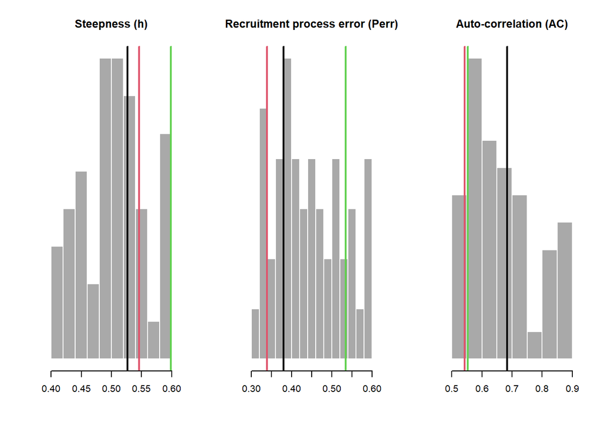

#### Time-Series

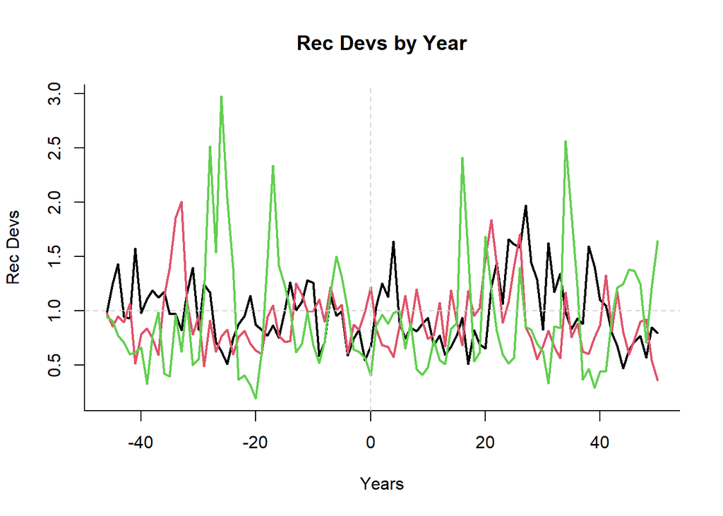

### Growth: Linf, K, t0, LenCV, Ksd, Linfsd

**Linf**: Maximum length. Uniform distribution lower and upper bounds. Positive real numbers

Specified Value(s): 109, 145

The von Bertalanffy equation may not the best model for describing growth (Ebert et al. 1999, Rogers-Bennett et al. 2003), and in particular does not describe the growth of the small individuals very well. However, given the existing size limit, the focus of the MSE model is on the larger size classes, which are usually better described by the von Bertalanffy model.

Currently, the DLMtool only includes the von Bertalanffy growth model, and parameters must be specified which most closely represent the growth of the species. Additionally, all the management procedures which use growth information assume a von Bertalanffy growth curve. It may be possible to add alternatives growth curves to the MSE model in the DLMtool, and develop alternative management procedures. However, given the uncertainty in growth and mortality parameters, it is unlikely that methods which rely on growth will be used for this species.

Roger-Bennett et al. (2003) fitted six different growth curves to data from northern California, and found that the logistic dose-response model provided the best fit to the data. The growth of red sea urchin is highly variable, and the estimates of the von Bertalanffy parameters from Roger-Bennett et al. (2003) and Ebert et al. (1999) were used to determine the range used in this study. No information exists on appropriate values for t0, and this was set to 0 for the study.

**K**: von Bertalanffy growth parameter k. Uniform distribution lower and upper bounds. Positive real numbers

Specified Value(s): 0.13, 0.3

See Linf

**t0**: von Bertalanffy theoretical age at length zero. Uniform distribution lower and upper bounds. Non-positive real numbers

Specified Value(s): 0, 0

See Linf

**LenCV**: Coefficient of variation of length-at-age (assumed constant for all age classes). Uniform distribution lower and upper bounds. Positive real numbers

Specified Value(s): 0.1, 0.15

No information, the default value was used.

**Ksd**: Inter-annual variability in growth parameter k expressed as coefficient of variation. Uniform distribution lower and upper bounds. Non-negative real numbers

Specified Value(s): 0, 0.03

No justification provided.

**Linfsd**: Inter-annual variability in maximum length expressed as a coefficient of variation. Uniform distribution lower and upper bounds. Non-negative real numbers

Specified Value(s): 0, 0.03

No justification provided.

### Growth Parameters

#### Sampled Parameters

Histograms of simulations of von Bertalanffy growth parameters `Linf`, `K`, and `t0`, and inter-annual variability in Linf and K (`Linfsd` and `Ksd`), with vertical colored lines indicating 3 randomly drawn values used in other plots:

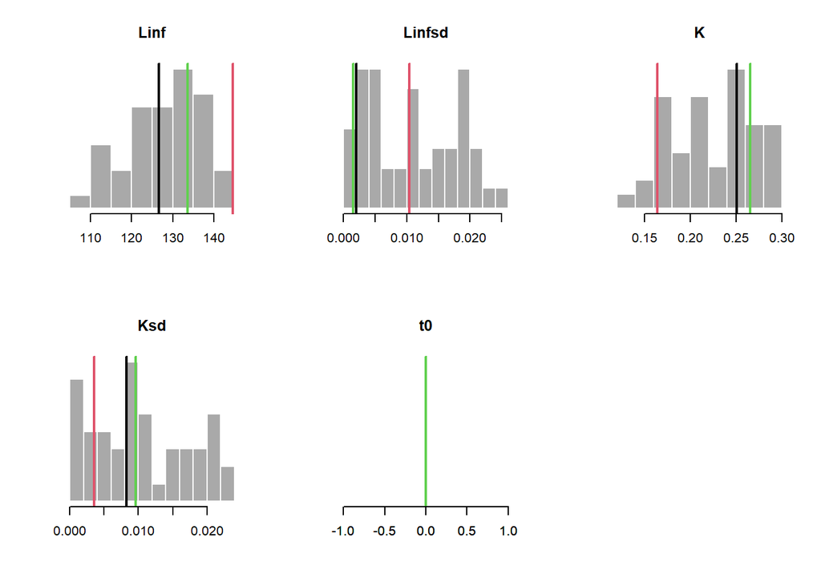

#### Time-Series

The Linf and K parameters in each year for 3 simulations. The vertical dashed line indicates the end of the historical period:

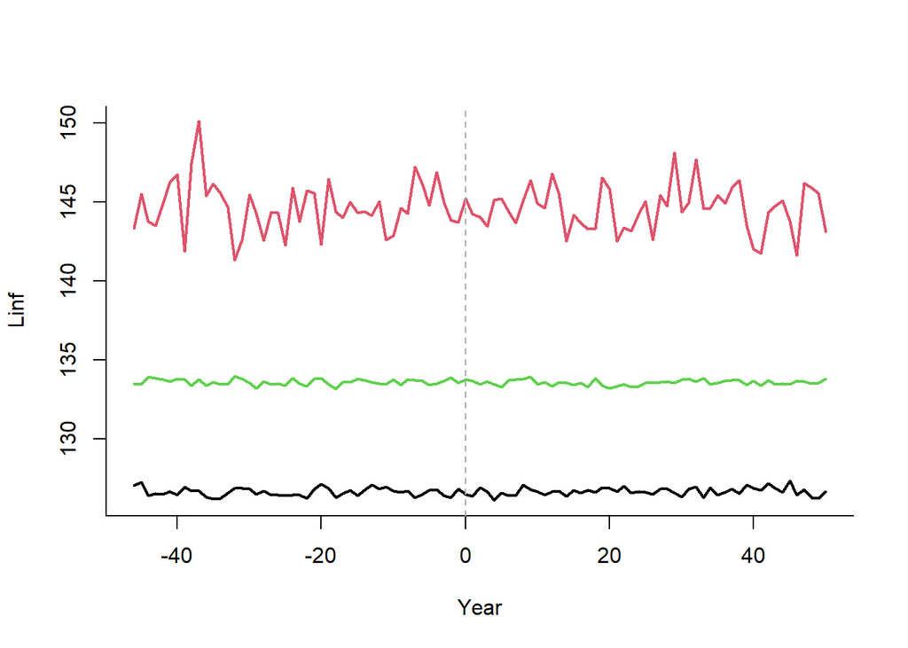

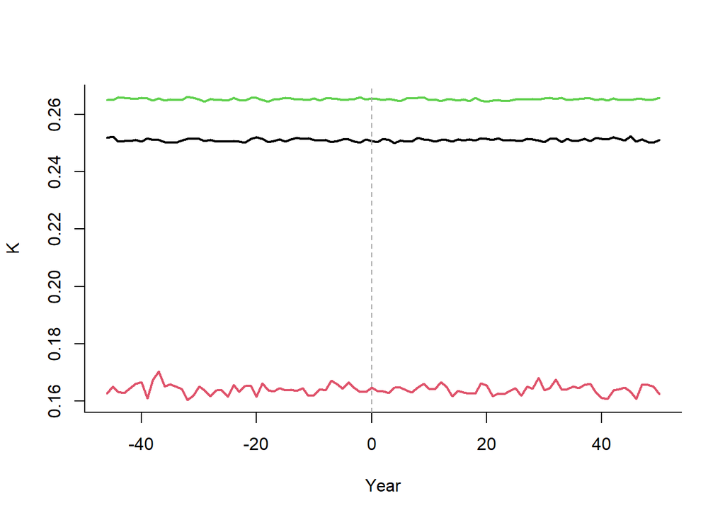

#### Growth Curves

Sampled length-at-age curves for 3 simulations in the first historical year, the last historical year, and the last projection year.

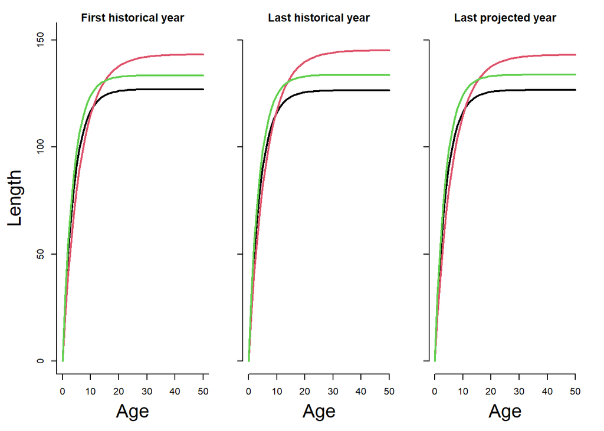

### Maturity: L50, L50_95

**L50**: Length at 50 percent maturity. Uniform distribution lower and upper bounds. Positive real numbers

Specified Value(s): 31.5, 58.5

Most studies cite Bernard and Miller (1973) for information on the size-at-maturity (sexually mature at 40 – 50 mm test diameter). However, this study was conducted around Vancouver Island in Canada.

There does not appear to be any information on size-at-maturity from the  
southern California region. Given the paucity of available data, the range for length at 50% maturity (L50) was assumed to be 45 mm test diameter +/- 30% CV. Similarly, the difference between the length at 95% maturity and 50% maturity (L50_95) was assumed to be 10-30 mm.

**L50_95**: Length increment from 50 percent to 95 percent maturity. Uniform distribution lower and upper bounds. Positive real numbers

Specified Value(s): 10, 30

See L50

### Maturity Parameters

#### Sampled Parameters

Histograms of simulations of `L50` (length at 50% maturity), `L95` (length at 95% maturity), and corresponding derived age at maturity parameters (`A50` and `A95`), with vertical colored lines indicating 3 randomly drawn values used in other plots:

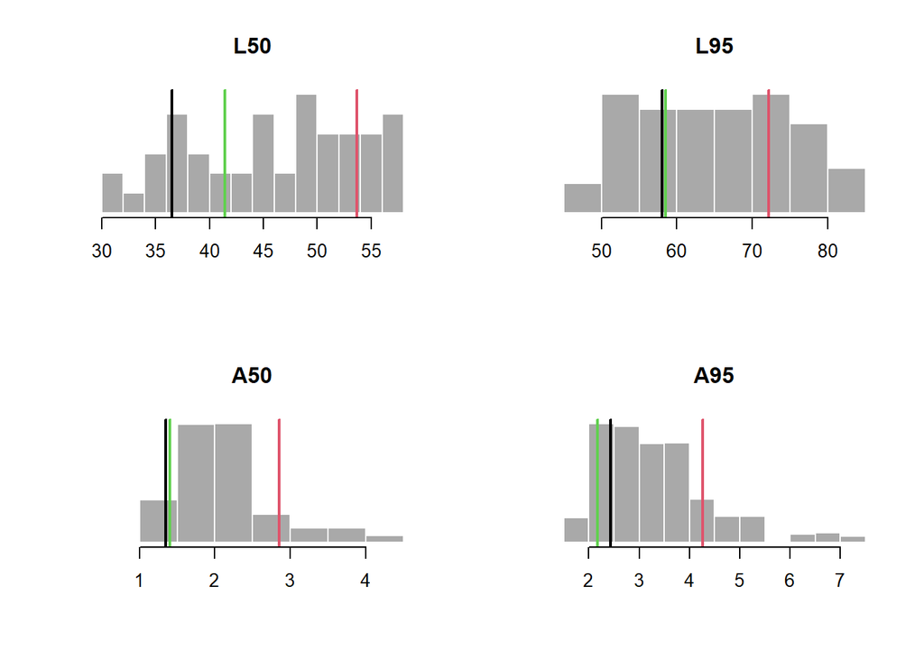

#### Maturity at Age and Length

Maturity-at-age and -length for 3 simulations in the first historical year, the last historical year (i.e., current year), and the last projected year:

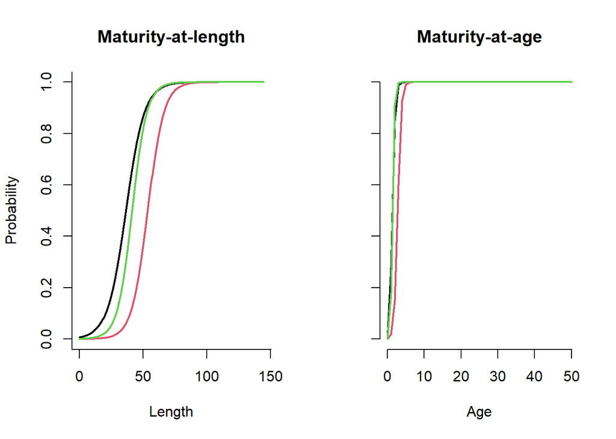

### Stock depletion and Discard Mortality: D, Fdisc

**D**: Current level of stock depletion SSB(current)/SSB(unfished). Uniform distribution lower and upper bounds. Fraction

Specified Value(s): 0.3, 0.6

No information exists on current level of depletion for the stock in southern California. A minimum legal length above the size of maturity has been in place since 1988, and 100% of the catch is mature. There does not appear to be any evidence of a decline in recruitment attributable to the fishery. Furthermore, it is estimated that 15-25% of the red sea urchin stock in California is in marine protected areas (MPAs) that are closed to all fishing activities.

Therefore, it is believed that the red sea urchin stock in southern California is not heavily depleted. The bounds for the depletion level were set at 0.3 - 0.6. Although the stock is not believed to be overfished, the lower bound was set to determine the performance of the MPs at lower stock levels, and to find a management procedure that was robust to a stock that was at a lower level of biomass.

**Fdisc**: Fraction of discarded fish that die. Uniform distribution lower and upper bounds. Non-negative real numbers

Specified Value(s): 0, 0

Discard mortality was not included in DLMtool at the time this OM was built. Recent versions of DLMtool now include discard mortality.

### Depletion and Discard Mortality

#### Sampled Parameters

Histograms of simulations of depletion (spawning biomass in the last historical year over average unfished spawning biomass; `D`) and the fraction of discarded fish that are killed by fishing mortality (`Fdisc`), with vertical colored lines indicating 3 randomly drawn values.

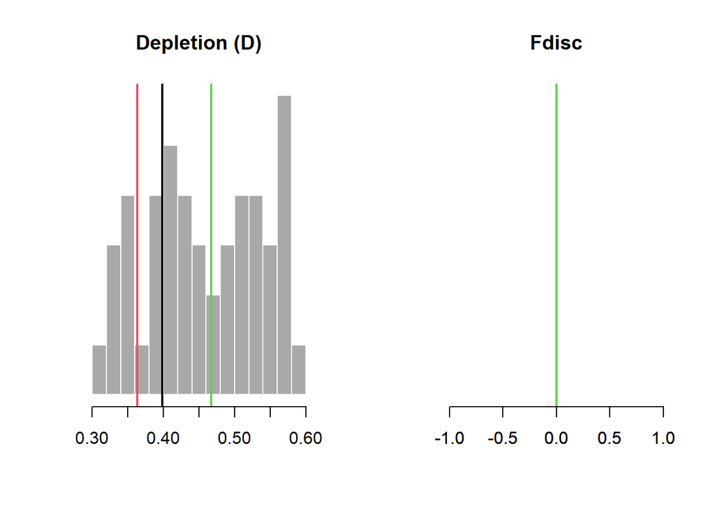

### Length-weight conversion parameters: a, b

**a**: Length-weight parameter alpha. Single value. Positive real number

Specified Value(s): 0

No estimates for the length-weight parameters exist for California. The MSE model is not sensitive to these parameters, and values from a Canadian study were used (Campbell 1998).

**b**: Length-weight parameter beta. Single value. Positive real number

Specified Value(s): 2.71

See above

### Spatial distribution and movement: Size_area_1, Frac_area_1, Prob_staying

**Size_area_1**: The size of area 1 relative to area 2. Uniform distribution lower and upper bounds. Positive real numbers

Specified Value(s): 0.15, 0.25

The Size_area_1 slot was not included in DLMtool at the time of this analyis. For this OM this Size_area_1  
has been set equal to Frac_area_1 which assumes equal density in Area 1 and Area 2.

**Frac_area_1**: The fraction of the unfished biomass in stock 1. Uniform distribution lower and upper bounds. Positive real numbers

Specified Value(s): 0.15, 0.25

Sea urchin are relatively sedentary, and the probability of staying in a spatial area (Prob_staying) was set to a high value of 0.95 - 0.99.

It is believed that 15 - 25% of the red sea urchin stock is within the MPA network in southern California, and the fraction of the stock in area 1 (Frac_area_1) was set to 0.15 - 0.25.

**Prob_staying**: The probability of individuals in area 1 remaining in area 1 over the course of one year. Uniform distribution lower and upper bounds. Positive fraction.

Specified Value(s): 0.95, 0.99

See Frac_area_1

### Spatial & Movement

#### Sampled Parameters

Histograms of 48 simulations of size of area 1 (`Size_area_1`), fraction of unfished biomass in area 1 (`Frac_area_1`), and the probability of staying in area 1 in a year (`Frac_area_1`), with vertical colored lines indicating 3 randomly drawn values used in other plots:

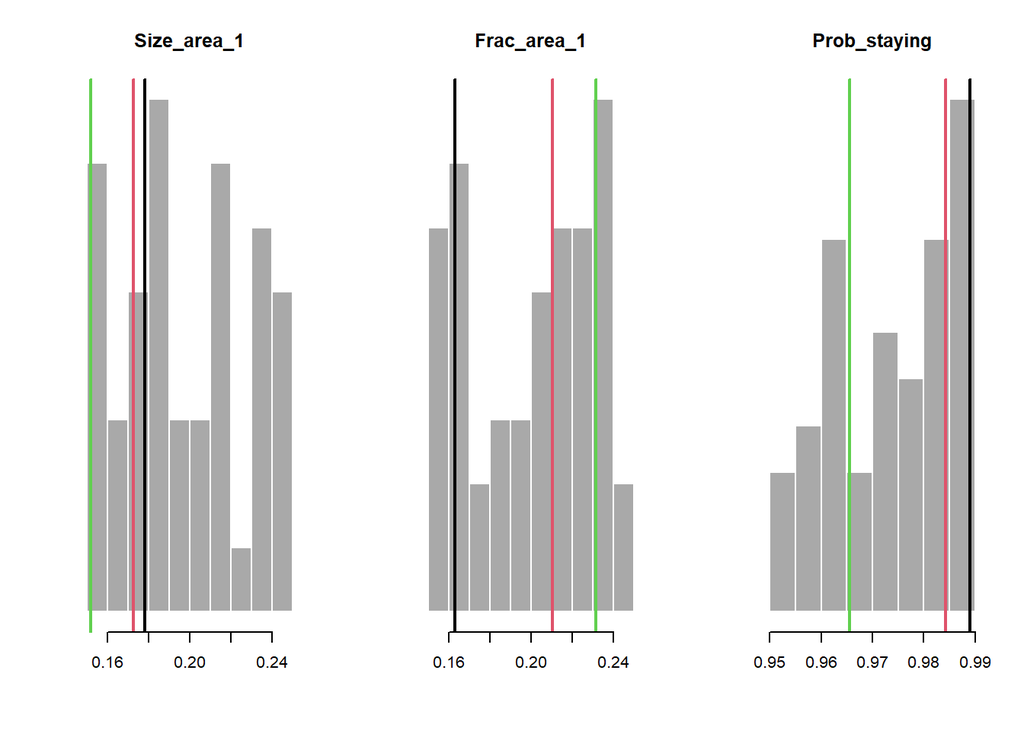

# Fleet Parameters

### Historical years of fishing, spatial targeting: nyears, Spat_targ

**nyears**: The number of years for the historical spool-up simulation. Single value. Positive integer

Specified Value(s): 47

The fishery for red sea urchin in southern California began in the early 1970s, and 47-year (1970 – 2016) fishing history was assumed.

**Spat_targ**: Distribution of fishing in relation to spatial biomass: fishing distribution is proportional to B^Spat_targ. Uniform distribution lower and upper bounds. Real numbers

Specified Value(s): 1, 1

Targeting was assumed proportional to biomass.

### Trend in historical fishing effort (exploitation rate), interannual variability in fishing effort: EffYears, EffLower, EffUpper, Esd

**EffYears**: Years representing join-points (vertices) of time-varying effort. Vector. Non-negative real numbers

The number of active permitees in the fishery was used as a proxy for historical fishing effort. The permits were introduced in the mid-1980s, and the number of active divers decreased during the next two decades, and appears to have been relatively stable since 2005.

Fishing mortality generally increased from 1970 to the mid-1980s, then gradually decreased until 2005 and has been relatively stable since.

**EffLower**: Lower bound on relative effort corresponding to EffYears. Vector. Non-negative real numbers

See EffYears

**EffUpper**: Upper bound on relative effort corresponding to EffYears. Vector. Non-negative real numbers

See EffYears

[output not shown]

**Esd**: Additional inter-annual variability in fishing mortality rate. Uniform distribution lower and upper bounds. Non-negative real numbers

Specified Value(s): 0.1, 0.4

Default values from DLMtool were used for the inter-annual variability in fishing mortality.

### Historical Effort

#### Sampled Parameters

Histograms of 48 simulations of inter-annual variability in historical fishing mortality (`Esd`), with vertical colored lines indicating 3 randomly drawn values used in the time-series plot:

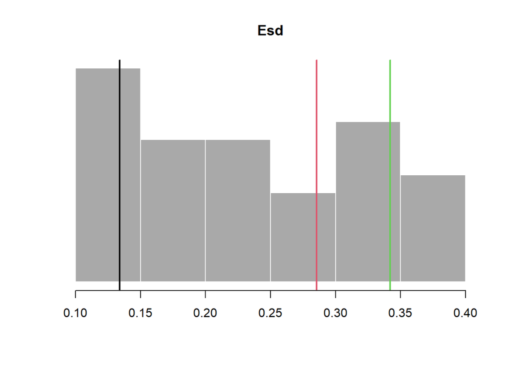

#### Time-Series

Time-series plot showing 3 trends in historical fishing mortality (`OM@EffUpper` and `OM@EffLower` or `OM@cpars$Find`):

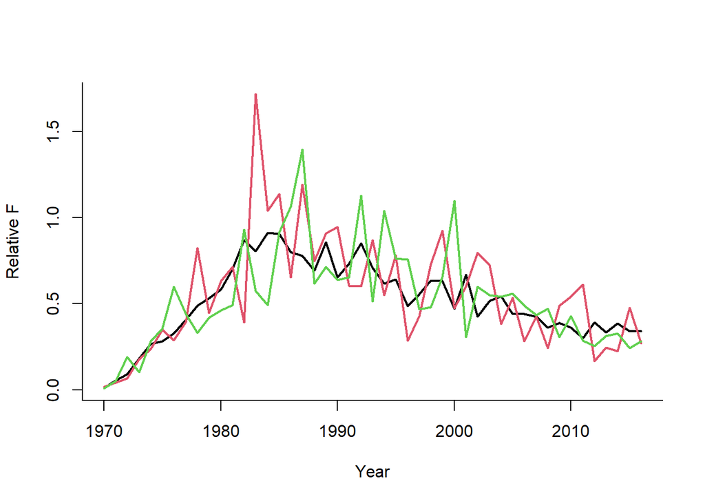

### Annual increase in catchability, interannual variability in catchability: qinc, qcv

**qinc**: Average percentage change in fishing efficiency (applicable only to forward projection and input controls). Uniform distribution lower and upper bounds. Non-negative real numbers

Specified Value(s): 0, 2

Default values from DLMtool were used for the annual increase in catchability.

**qcv**: Inter-annual variability in fishing efficiency (applicable only to forward projection and input controls). Uniform distribution lower and upper bounds. Non-negative real numbers

Specified Value(s): 0.1, 0.3

Default values from DLMtool were used for the annual variability in catchability.

### Future Catchability

#### Sampled Parameters

Histograms of 48 simulations of inter-annual variability in fishing efficiency (`qcv`) and average annual change in fishing efficiency (`qinc`), with vertical colored lines indicating 3 randomly drawn values used in the time-series plot:

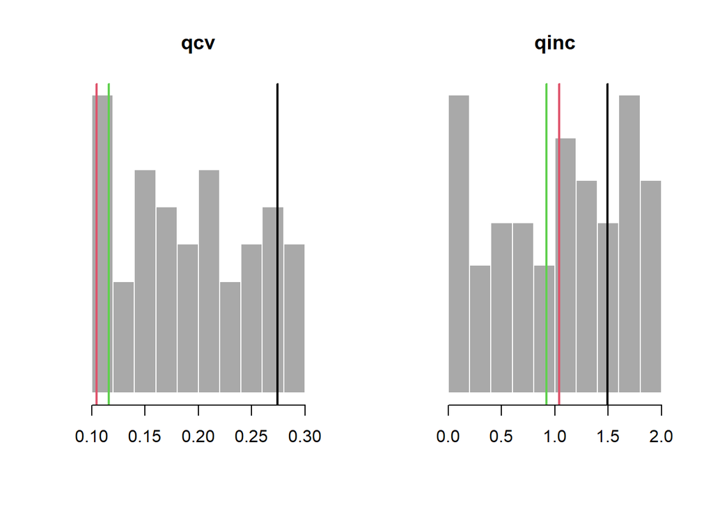

#### Time-Series

Time-series plot showing 3 trends in future fishing efficiency (catchability):

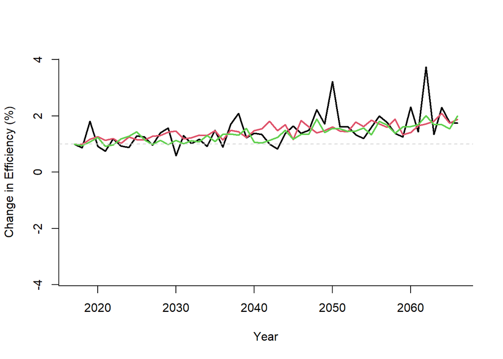

### Fishery gear length selectivity: L5, LFS, Vmaxlen, isRel

**L5**: Shortest length corresponding to 5 percent vulnerability. Uniform distribution lower and upper bounds. Positive real numbers

Specified Value(s): 0, 0

Not used. See SelYears below.

**LFS**: Shortest length that is fully vulnerable to fishing. Uniform distribution lower and upper bounds. Positive real numbers

Specified Value(s): 0, 0

Not used. See SelYears below.

**Vmaxlen**: The vulnerability of fish at Stock@Linf . Uniform distribution lower and upper bounds. Fraction

Specified Value(s): 0, 0

Not used. See SelYears below.

**isRel**: Selectivity parameters in units of size-of-maturity (or absolute eg cm). Single value. Boolean

Specified Value(s): FALSE

Selectivity was specified in absolute units.

### Fishery length retention: LR5, LFR, Rmaxlen, DR

**LR5**: Shortest length corresponding ot 5 percent retention. Uniform distribution lower and upper bounds. Non-negative real numbers

Specified Value(s): 0, 0

This slot was not included in DLMtool at the time the OM was built. The retention curve is assumed to be equivalent to the selectivity curve, which is probably a reasonable assumption in this dive fishery.

**LFR**: Shortest length that is fully retained. Uniform distribution lower and upper bounds. Non-negative real numbers

Specified Value(s): 0, 0

See LR5

**Rmaxlen**: The retention of fish at Stock@Linf . Uniform distribution lower and upper bounds. Non-negative real numbers

Specified Value(s): 1, 1

See LR5

**DR**: Discard rate - the fraction of caught fish that are discarded. Uniform distribution lower and upper bounds. Fraction

Slot not used.

### Current Year: CurrentYr

**CurrentYr**: The current calendar year (final year) of the historical simulations (eg 2011). Single value. Positive integer

Specified Value(s): 2016

The most recent data was from 2016

### Existing Spatial Closures: MPA

**MPA**: Is Area 1 currently closed (TRUE) or open (FALSE)? Defaults to FALSE

Specified Value(s): FALSE

This slot was not included in DLMtool at the time the OM was built. Historical MPAs have now been included in recent versions of DLMtool.

# Obs Parameters

Except where information was found to suggest alternative values, the parameters used for the observation model were based on the values presented in Carruthers et al. (2014) and are found in the ‘Generic_Obs’ observation object in the DLMtool.

### Catch statistics: Cobs, Cbiascv, CAA_nsamp, CAA_ESS, CAL_nsamp, CAL_ESS

**Cobs**: Log-normal catch observation error expressed as a coefficient of variation. Uniform distribution lower and upper bounds. Non-negative real numbers

Specified Value(s): 0.1, 0.3

Borrowed from Generic_Obs

**Cbiascv**: Log-normal coefficient of variation controlling the sampling of bias in catch observations for each simulation. Single value. Non-negative real number

Specified Value(s): 0.1

Borrowed from Generic_Obs

**CAA_nsamp**: Number of catch-at-age observation per time step. Uniform distribution lower and upper bounds. Positive real numbers

Specified Value(s): 100, 200

Borrowed from Generic_Obs

**CAA_ESS**: Effective sample size (independent age draws) of the multinomial catch-at-age observation error model. Uniform distribution lower and upper bounds. Positive integers

Specified Value(s): 10, 20

The effective sample size for catch-at-age was reduced to 10 – 20 to reflect the paucity of this type of data.

**CAL_nsamp**: Number of catch-at-length observation per time step. Uniform distribution lower and upper bounds. Positive integers

Specified Value(s): 100, 200

Borrowed from Generic_Obs

**CAL_ESS**: Effective sample size (independent length draws) of the multinomial catch-at-length observation error model. Uniform distribution lower and upper bounds. Positive integers

Specified Value(s): 25, 50

Borrowed from Generic_Obs

### Index imprecision, bias and hyperstability: Iobs, Btobs, Btbiascv, beta

**Iobs**: Observation error in the relative abundance indices expressed as a coefficient of variation. Uniform distribution lower and upper bounds. Positive real numbers

Specified Value(s): 0.1, 0.4

Borrowed from Generic_Obs

**Btobs**: Log-normal coefficient of variation controlling error in observations of current stock biomass among years. Uniform distribution lower and upper bounds. Positive real numbers

Specified Value(s): 0.33, 3

Borrowed from Generic_Obs

**Btbiascv**: Uniform-log bounds for sampling persistent bias in current stock biomass. Uniform-log distribution lower and upper bounds. Positive real numbers

Specified Value(s): 0.2, 0.5

Borrowed from Generic_Obs

**beta**: A parameter controlling hyperstability/hyperdepletion where values below 1 lead to hyperstability (an index that decreases slower than true abundance) and values above 1 lead to hyperdepletion (an index that decreases more rapidly than true abundance). Uniform distribution lower and upper bounds. Positive real numbers

Specified Value(s): 0.8, 1.2

The range for the beta parameter was set to 0.8 – 1.2 to reflect the perceived increased reliability of CPUE data for this stock compared to the ‘Generic_obs’ default values.

### Bias in maturity, natural mortality rate and growth parameters: LenMbiascv, Mbiascv, Kbiascv,t0biascv, Linfbiascv

**LenMbiascv**: Log-normal coefficient of variation for sampling persistent bias in length at 50 percent maturity. Single value. Positive real numbers

Specified Value(s): 0.1

Borrowed from Generic_Obs

**Mbiascv**: Log-normal coefficient of variation for sampling persistent bias in observed natural mortality rate. Single value. Positive real number

Specified Value(s): 0.3

The CV for natural mortality was increased to 30% to reflect the uncertainty in this parameter.

**Kbiascv**: Log-normal coefficient of variation for sampling persistent bias in observed growth parameter K. Single value. Positive real number

Specified Value(s): 0.2

The CV for the growth (Linf and K) parameters was increased to 10% and 20% respectively to reflect high uncertainty in these parameters.

**t0biascv**: Log-normal coefficient of variation for sampling persistent bias in observed t0. Single value. Positive real number

Specified Value(s): 0.1

Borrowed from Generic_Obs

**Linfbiascv**: Log-normal coefficient of variation for sampling persistent bias in observed maximum length. Single value. Positive real number

Specified Value(s): 0.1

See Kbiascv

### Bias in length at first capture, length at full selection: LFCbiascv, LFSbiascv

**LFCbiascv**: Log-normal coefficient of variation for sampling persistent bias in observed length at first capture. Single value. Positive real number

Specified Value(s): 0.05

Borrowed from Generic_Obs

**LFSbiascv**: Log-normal coefficient of variation for sampling persistent bias in length-at-full selection. Single value. Positive real number

Specified Value(s): 0.05

Borrowed from Generic_Obs

### Bias in fishery reference points, unfished biomass, FMSY, FMSY/M ratio, biomass at MSY relative to unfished: FMSY_Mbiascv, BMSY_B0biascv

**FMSY_Mbiascv**: Log-normal coefficient of variation for sampling persistent bias in FMSY/M. Single value. Positive real number

Specified Value(s): 0.2

Borrowed from Generic_Obs

**BMSY_B0biascv**: Log-normal coefficient of variation for sampling persistent bias in BMSY relative to unfished. Single value. Positive real number

Specified Value(s): 0.2

Borrowed from Generic_Obs

### Management targets in terms of the index (i.e., model free), the total annual catches and absolute biomass levels: Irefbiascv, Crefbiascv, Brefbiascv

**Irefbiascv**: Log-normal coefficient of variation for sampling persistent bias in relative abundance index at BMSY. Single value. Positive real number

Specified Value(s): 0.2

Borrowed from Generic_Obs

**Crefbiascv**: Log-normal coefficient of variation for sampling persistent bias in MSY. Single value. Positive real number

Specified Value(s): 0.2

Borrowed from Generic_Obs

**Brefbiascv**: Log-normal coefficient of variation for sampling persistent bias in BMSY. Single value. Positive real number

Specified Value(s): 0.5

Borrowed from Generic_Obs

### Depletion bias and imprecision: Dbiascv, Dobs

**Dbiascv**: Log-normal coefficient of variation for sampling persistent bias in stock depletion. Single value. Positive real number

Specified Value(s): 0.5

Borrowed from Generic_Obs

**Dobs**: Log-normal coefficient of variation controlling error in observations of stock depletion among years. Uniform distribution lower and upper bounds. Positive real numbers

Specified Value(s): 0.05, 0.1

Borrowed from Generic_Obs

### Recruitment compensation and trend: hbiascv, Recbiascv, sigmaRbiascv

**hbiascv**: Log-normal coefficient of variation for sampling persistent bias in steepness. Single value. Positive real number

Specified Value(s): 0.2

Borrowed from Generic_Obs

**Recbiascv**: Log-normal coefficient of variation for sampling persistent bias in recent recruitment strength. Uniform distribution lower and upper bounds. Positive real numbers

Specified Value(s): 0.1, 0.3

Borrowed from Generic_Obs

**sigmaRbiascv**: Log-normal coefficeint of variation for sampling persistent bias in recruitment variability. Single value. Positive real number

Specified Value(s): 0.1

No justification provided.

### Effort: Eobs, Ebiascv

**Eobs**: Log-normal effort observation error expressed as a coefficient of variation. Uniform distribution lower and upper bounds. Non-negative real numbers

Slot not used.

**Ebiascv**: Log-normal coefficient of variation controlling the sampling of bias in effort observations for each simulation. Single value. Non-negative real number

Slot not used.

## Observation Parameters

### Catch Observations

#### Sampled Parameters

Histograms of 48 simulations of inter-annual variability in catch observations (`Csd`) and persistent bias in observed catch (`Cbias`), with vertical colored lines indicating 3 randomly drawn values used in other plots:

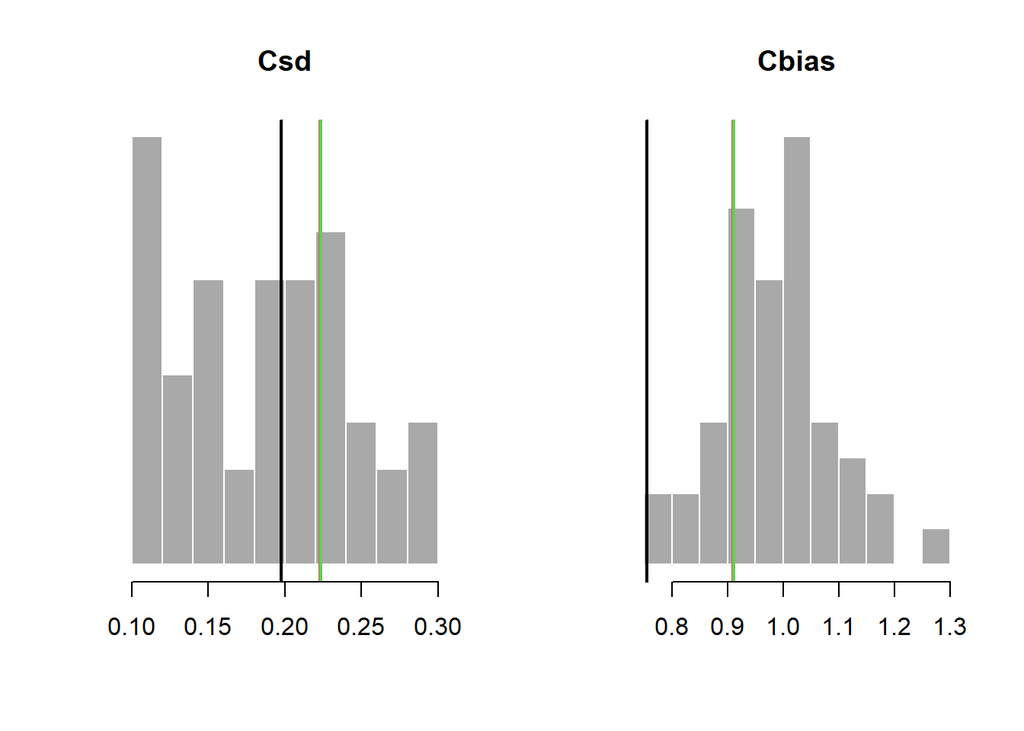

#### Time-Series

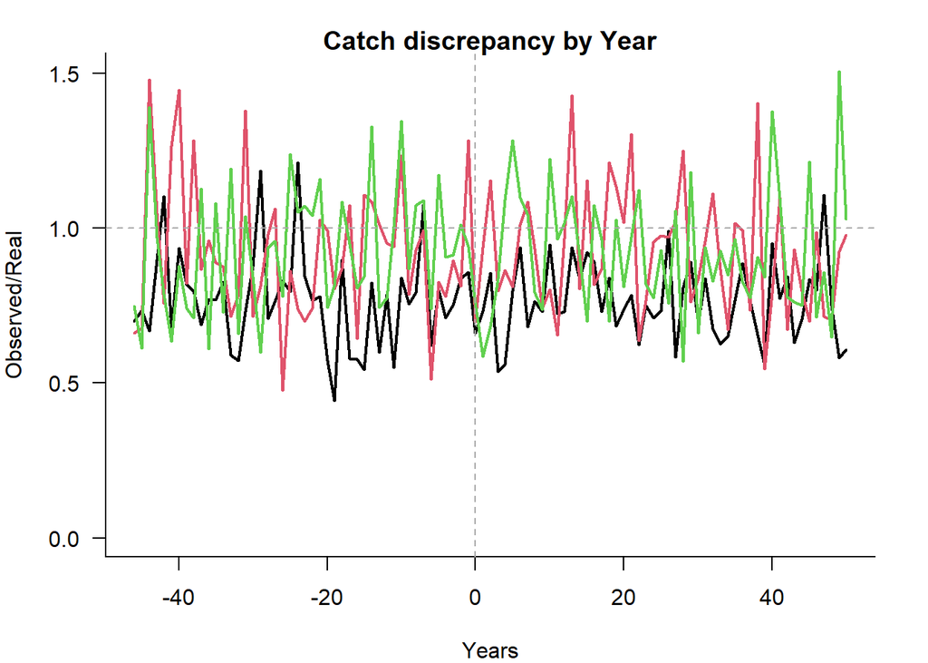

### Depletion Observations

#### Sampled Parameters

Histograms of 48 simulations of inter-annual variability in depletion observations (`Dobs`) and persistent bias in observed depletion (`Dbias`), with vertical colored lines indicating 3 randomly drawn values used in other plots:

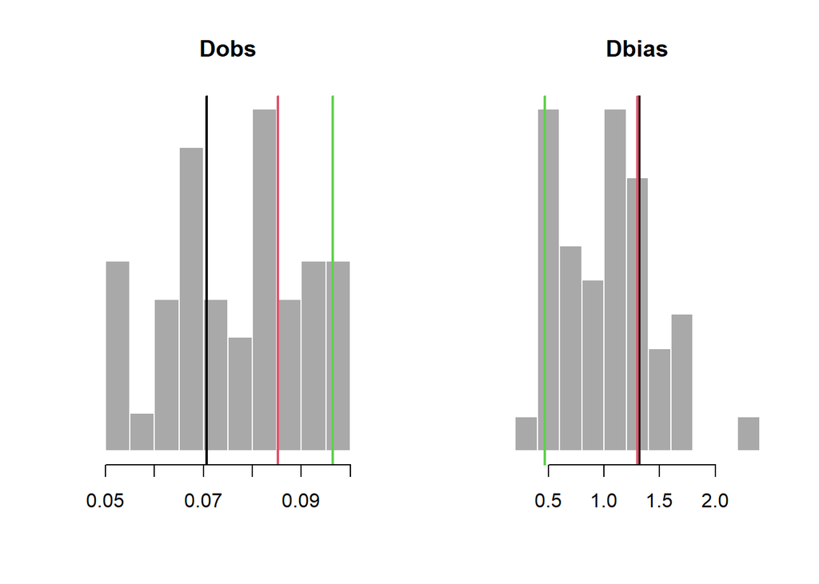

#### Time-Series

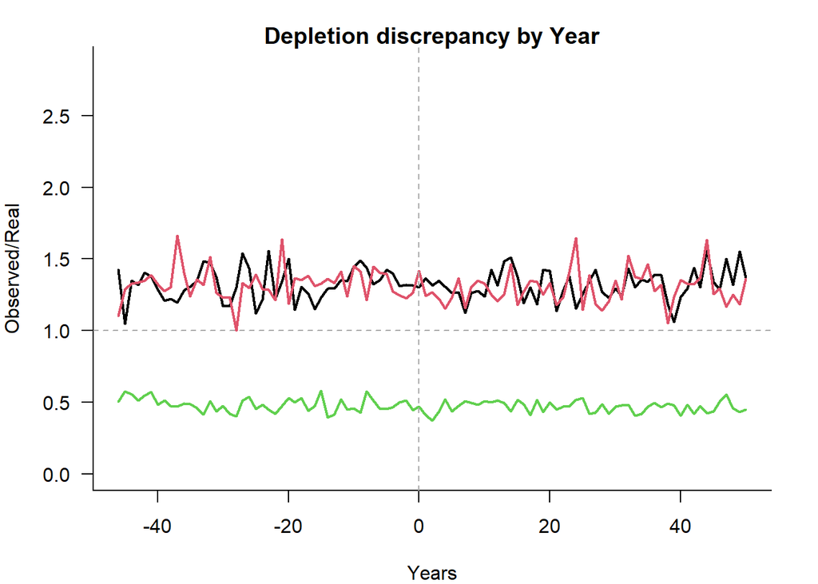

### Abundance Observations

#### Sampled Parameters

Histograms of 48 simulations of inter-annual variability in abundance observations (`Btobs`) and persistent bias in observed abundance (`Btbias`), with vertical colored lines indicating 3 randomly drawn values used in other plots:

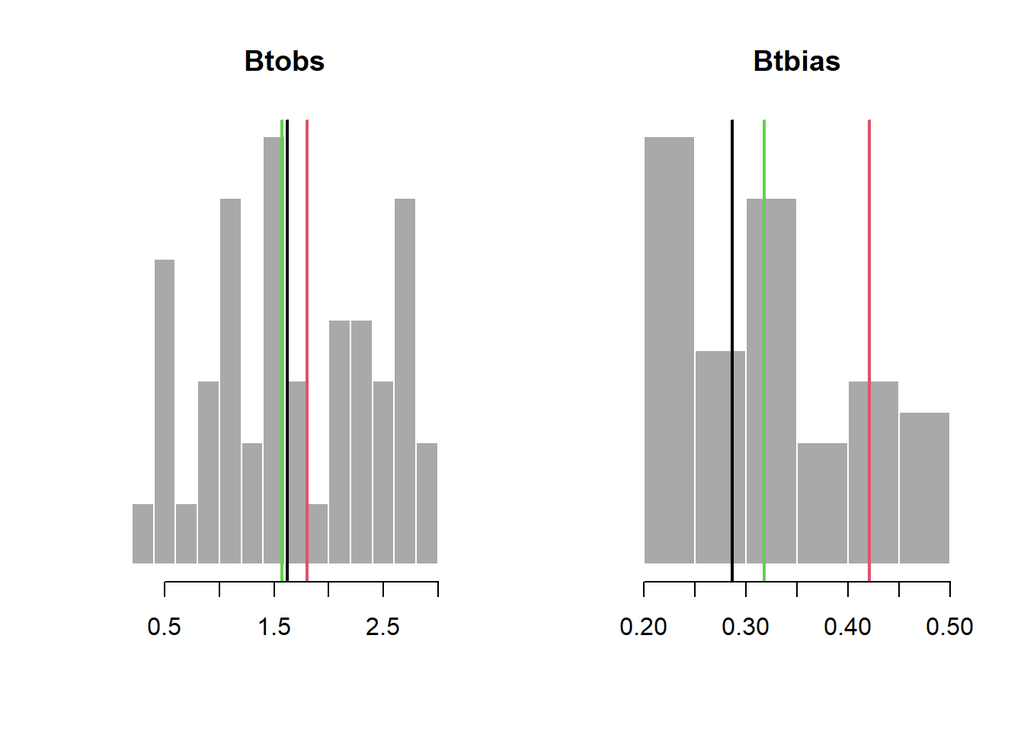

#### Time-Series

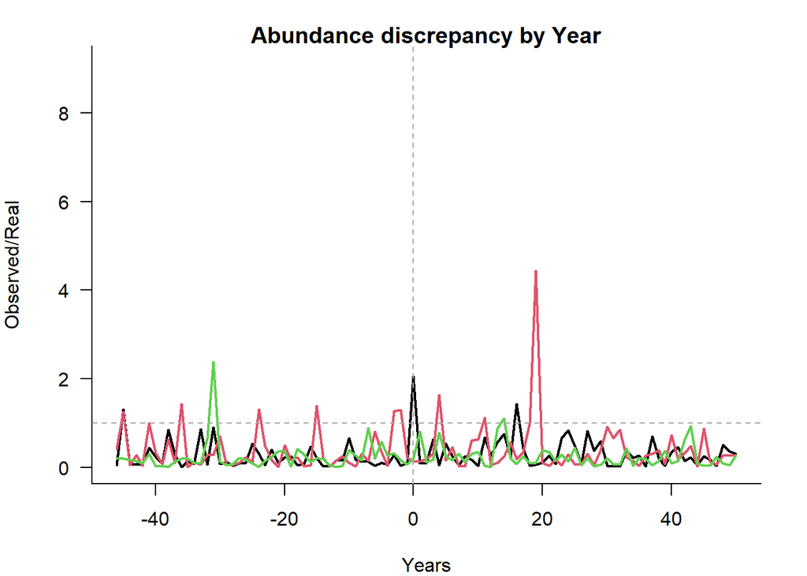

### Index Observations

#### Sampled Parameters

Histograms of 48 simulations of inter-annual variability in index observations (`Iobs`) and hyper-stability/depletion in observed index (`beta`), with vertical colored lines indicating 3 randomly drawn values used in other plots:

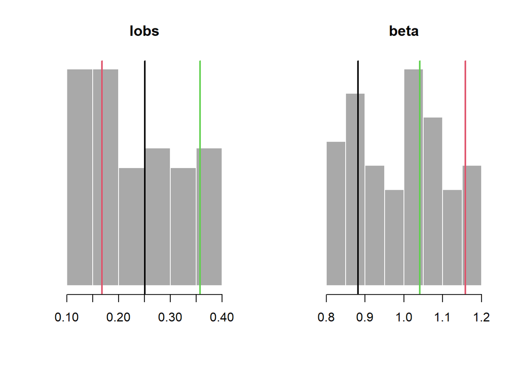

#### Time-Series

Time-series plot of 3 samples of index observation error:

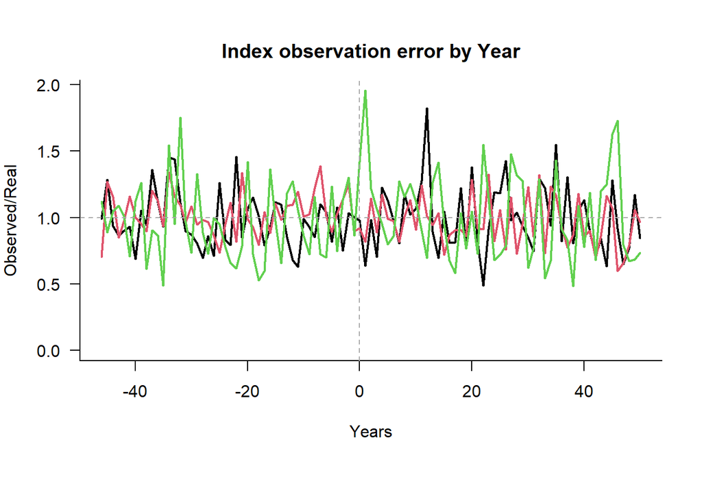

Plot showing an example true abundance index (blue) with 3 samples of index observation error and the hyper-stability/depletion parameter (`beta`):

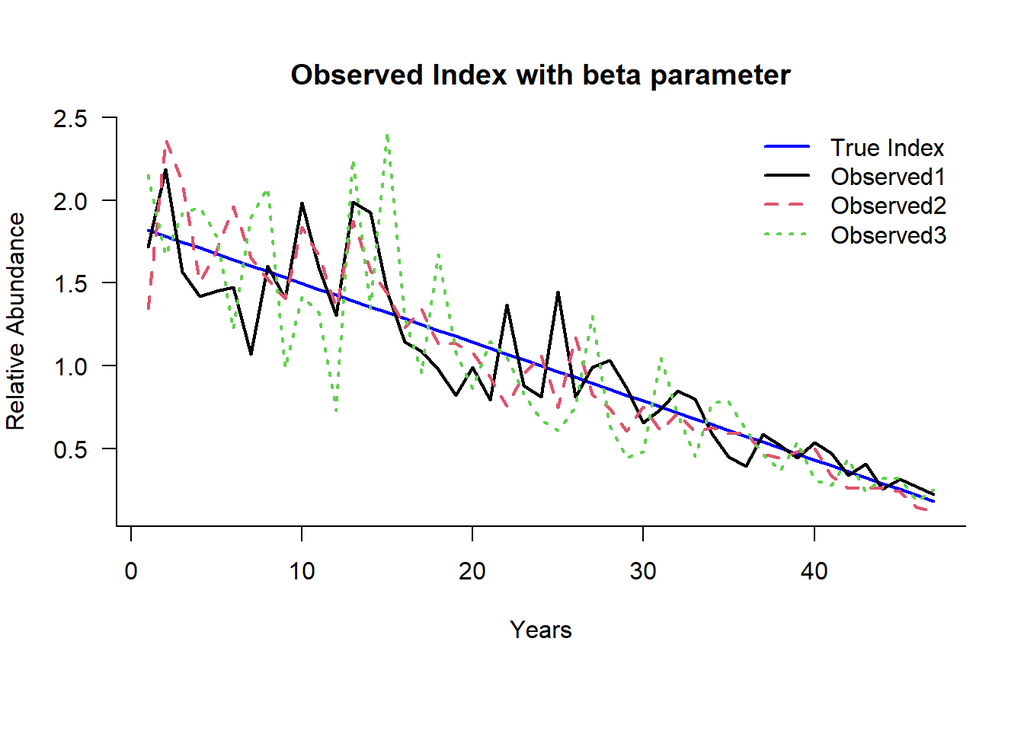

### Recruitment Observations

#### Sampled Parameters

Histograms of 48 simulations of inter-annual variability in index observations (`Recsd`) , with vertical colored lines indicating 3 randomly drawn values used in other plots:

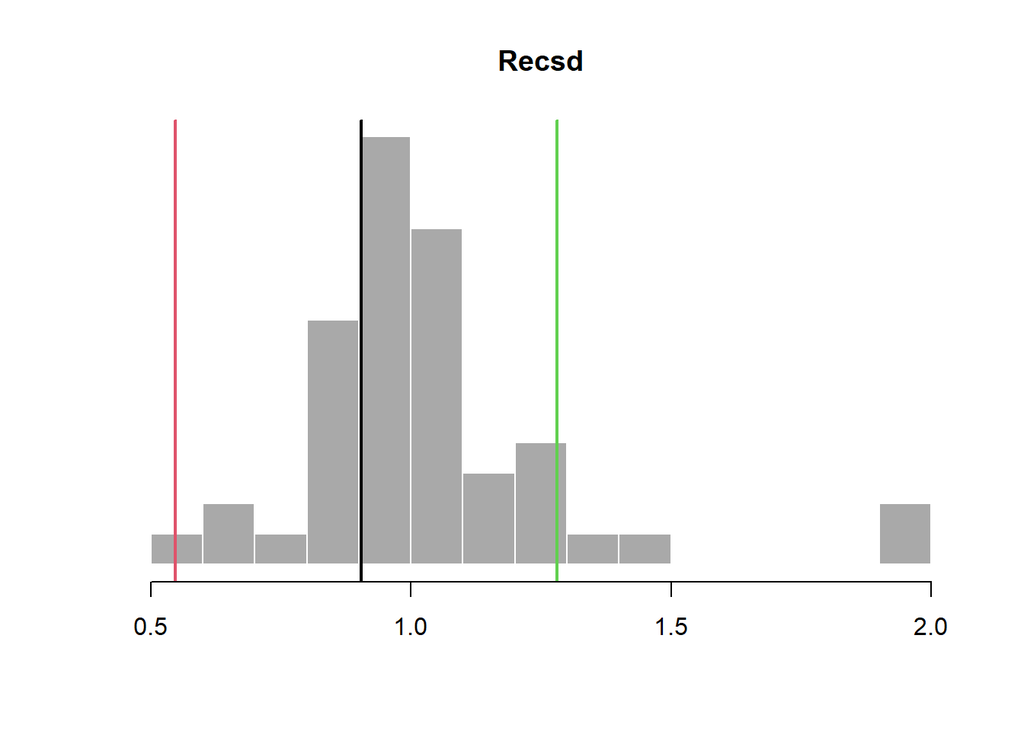

#### Time-Series

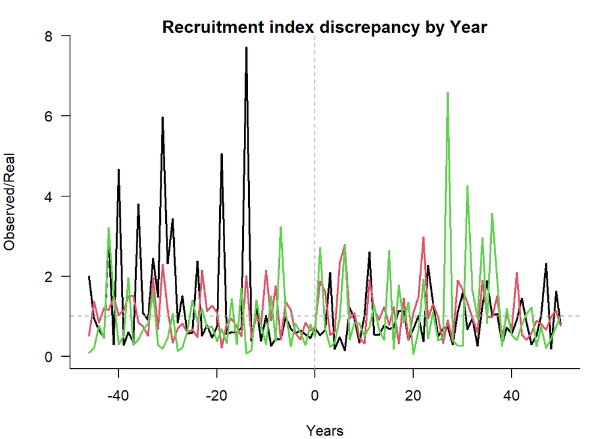

### Composition Observations

#### Sampled Parameters

Histograms of 48 simulations of catch-at-age effective sample size (`CAA_ESS`) and sample size (`CAA_nsamp`) and catch-at-length effective (`CAL_ESS`) and actual sample size (`CAL_nsamp`) with vertical colored lines indicating 3 randomly drawn values:

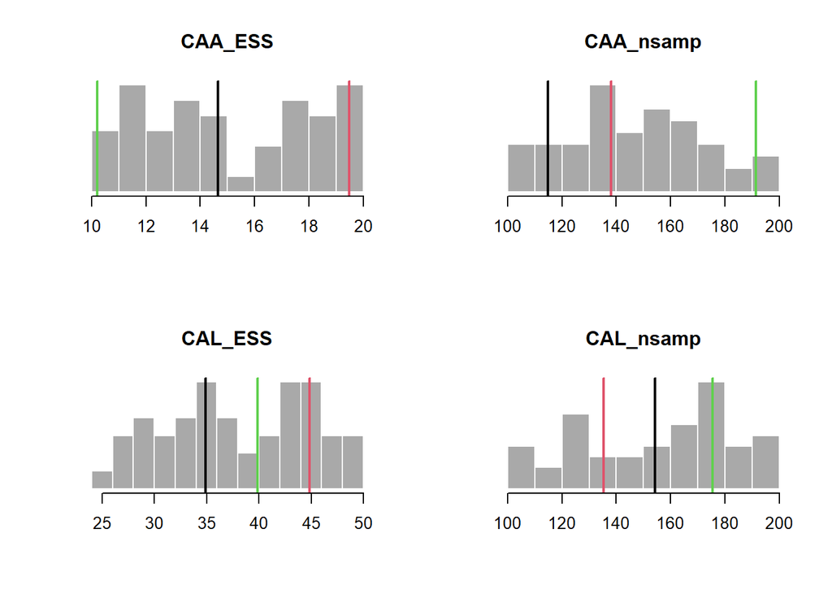

### Parameter Observations

#### Sampled Parameters

Histograms of 48 simulations of bias in observed natural mortality (`Mbias`), von Bertalanffy growth function parameters (`Linfbias`, `Kbias`, and `t0bias`), length-at-maturity (`lenMbias`), and bias in observed length at first capture (`LFCbias`) and first length at full capture (`LFSbias`) with vertical colored lines indicating 3 randomly drawn values:

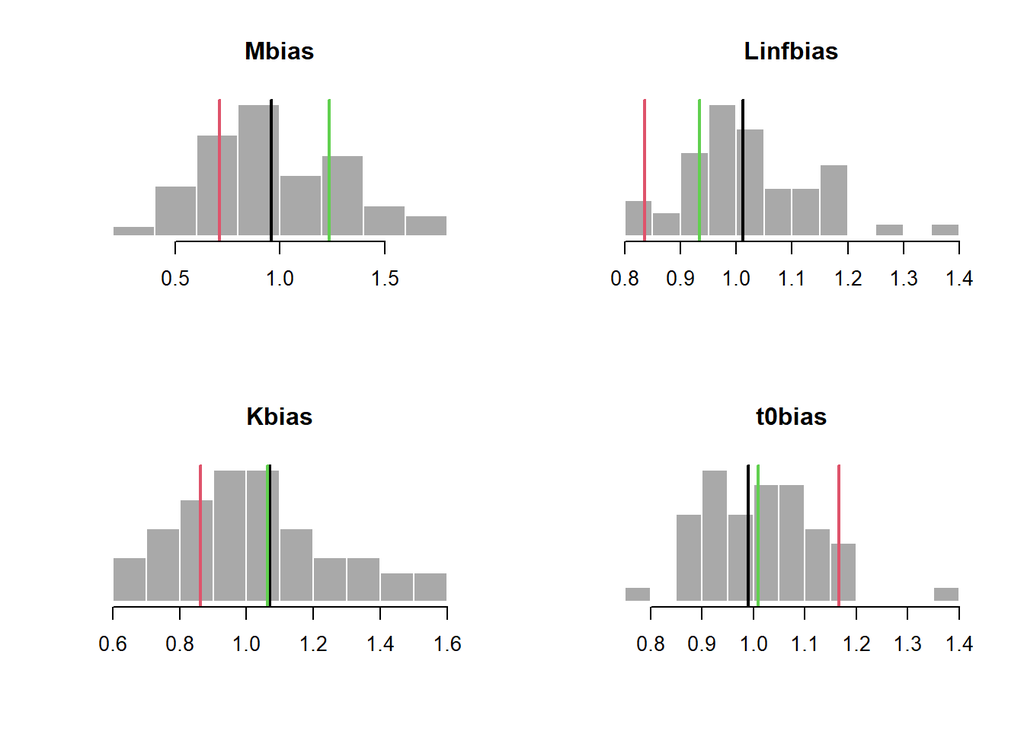

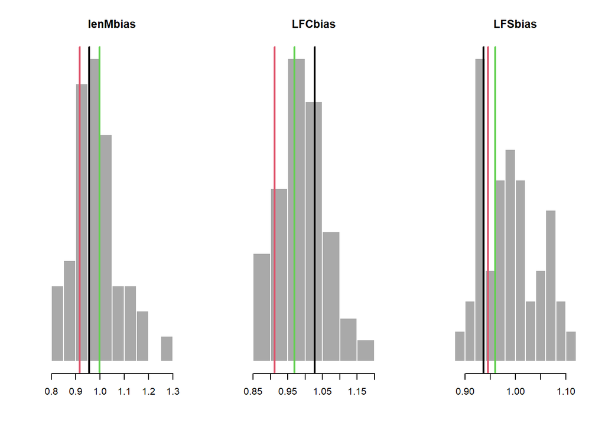